# The Influence of Colour on Ratings of Attractiveness

*N* removed NAs: 3

*N* removed typo: 1

*N* removed <18: 25

*N* total clean: 121

| Group | *N* | *M*<sub>age</sub> | *M*<sub>rating</sub> |
| --- | --- | --- | --- |
| Control | 66 | 20.7 | 6.90 |
| Experim | 55 | 20.8 | 5.79 |

**Main analysis results**

*t*(119) = 8.29, *p* < .001

[interactive chart not shown]

[figure not shown]

[interactive chart not shown]

# The Influence of Colour on Ratings of Attractiveness

Analysing Data, Spring 2020

# Methods

## Participants

Table 1: Descriptive statistics by age and condition

| condition | N | % | Mean age | SD age |
| --- | --- | --- | --- | --- |
| White | 66 | 54.5 | 20.7 | 1.95 |
| Red | 55 | 45.5 | 20.8 | 2.00 |

## Design

The conceptual hypothesis of this study asks whether or not colour influences attractivenes. More specifically, do women find men more attractive in conjunction to the colour red? This is a replication of the study carried out by Elliot et al. (2010) who studied the same hypothesis.

There were 2 variables in this study that needed operationalising: colour and attractiveness. Colour was operationalised as a factor based on which colour participants in either condition saw - participants in the control conditon viewed a picture of a moderately attractive man with a white frame surroudning it, and participants in the experimental condition viewed a picutre of a moderately attractive man with a red frame around it. Therefore there were 2 levels to this variable- the colour red and the colour white. Attractiveness was operationalised using a 1-9 point rating scale on 3 questions:

1. How attractive do you think this person is to look at?
2. How pleasant is this person to look at?
3. If I were to meet the person in this picture face to face, I would think he is attractive.

A score of 9 indicated the highest level of attraction, whereas a score of 1 indicated no attraction at all. Answers were averaged to get a composite score for both conditions.

In this study, the test was whether or not colour affected attractiveness. Therefore the colour was the predictor, and the attractive ratings was the outcome.

The operational hypothesis of this study, then, was to investigate whether or not viewing a different colour frame around an image of a moderately attractive man had an effect on the mean rating of his attractiveness. This experiment used an independent measures design - particpants were assigned to one of two conditions (either red or white conditions) and only participated in the experiment of their assigned condition. As this experiment used an independent measures, a t-test will be used to test the hypothesis and to decide whether or not there is a significant difference between the control group and the experimental group.

# Results

To get an overview of what the general pattern of scores were, a composite score was calculated. In order to do this, participants indvidiual scores for the 3 rating scales were averaged into one score. These scores are demonstrated in the graph below, with the x axis representing the condition the individual participated in and the y axis representing the mean score for the 3 ratings. As we can see overall, participants in the white condition (this was the control group) generally gave higher ratings than those in the red condition (the experimental group). This shows an apparent difference in scores between the two conditions, however in order to get a clearer picture of the two groups, an overall score for the two conditions had to be calculated.

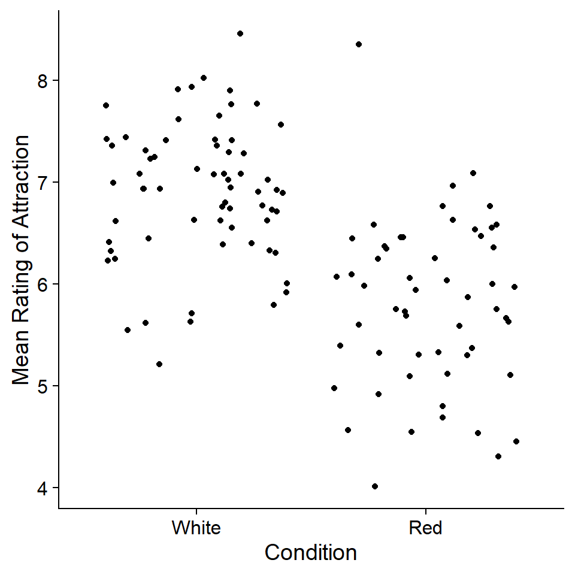

Figure: Participants Mean Score

To understand these scores clearly, the mean scores for each participant in both conditions were averaged together. This gives us a separate mean score for both conditions overall. These scores are shown in the table below. As can be seen, the mean score for the white condition is 6.90 and the mean score for the red condition is 5.79. Futhermore, the graph below shows a plot of these means with the standard error bars.

Table 2: Mean Scores by Condition

| Condition | N | Mean Score |
| --- | --- | --- |
| White | 66 | 6.90 |
| Red | 55 | 5.79 |

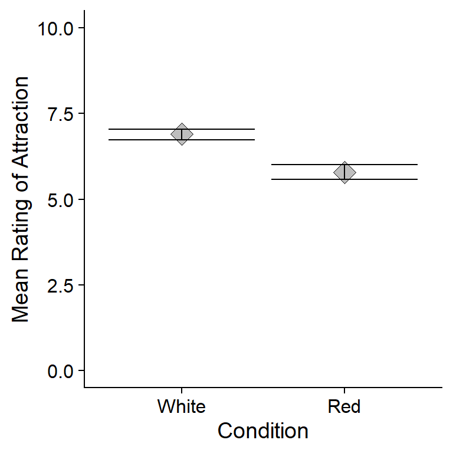

Mean Score for Each Condition

With these graphs and the table, we can see that in general the participants in the white condition gave higher ratings than those in the red condition. I used an independent measures t-test to quantify the relationship between these two groups and assess whether or not colour does have an impact on the ratings of attractiveness. I predicted that those in the red condition would report higher ratings of attraction towards the male confederate, however the *t*-test actually showed the opposite, showing that the mean ratings were higher in the white condiiton (*M*~diff = 1.11, 95% CI [0.85, 1.38]) and there was a significant difference between the two groups on ratings of attraction (*t* (119) = 8.29, *p* = .0000000).

# Discussion

Overall my data from the experiment shows that those in the white condition generally reported higher ratings of attractiveness than those in the red condition. This differs from what the original study conducted by Elliot et al (2010) found. This study found that women do in fact find men more attractive in conjunction to the colour red, with those who saw a red picture frame reporting higher ratings of attractiveness than those who saw a white picture frame. However, other replications of this study have also discovered different findings to this experiment. For example, some studies show that there is no effect of the colour red on attractiveness ratings (Hesslinger et al., 2015; Peperkoorn et al., 2016). A meta analyses of 9 different student replications also found this same pattern (Wagge et al., 2019). The results of my experiment seem to support these replications as opposed to the original experiment conducted by Elliott.

The lack of ability to replicate the original results suggests that there is another factor, rather than just the colour itself, that affects the attractiveness ratings. In Elliotts study, it is explained that the colour red is associated with higher status. Research has shown that women are more attracted to men who have higher status (DeWall & Maner, 2008) which would explain why those in the red condition of the original experiment reported higher ratings. However, why were these results not replicated in other experiments measuring the same thing? One reason for this lack of replication could be related to the meanings associated with the colours. The colour red is often associated with aggression and hostility (Seeing Red, 2014) whilst the colour white is sometimes associated with innocence and purity (Heller, 2000).Differences in ratings could be related to what association the particpant has with these colours and which association they value more.

In order to improve the current experimental method for testing this research question, future studies could assess the participants associations of the colours as well as testing whether these affect their attraction towards the confederate. It could be that it’s the meaning of the colour that has an effect rather than the colour itself. This could be tested by adding an additional procedure to the method, for example asking participants to answer the question “describe what you would expect this person to be like” or “what words and characteristics do you associate with the colour red/white”. Answering these will provide us with an idea of the affect colour can have on their perception towards people, and thus influencing their attraction towards them.

In conclusion, my results showed that women do not find men more attractive in conjunction to the colour red. This differs from the results of the original experiment. This suggests that there are problems with replicability, however I think that studying the question further is worthwhile to discover why there are differences in results and perhaps looking at associations to colours could be significant in answering that.

# References

DeWall, C. N., & Maner, J. K. (2008). High Status Men (but Not Women) Capture the Eye of the Beholder. *Evolutionary Psychology, 6*(2), 147470490800600. https://doi.org/10.1177/147470490800600209

Elliot, A. J., Niesta Kayser, D., Greitemeyer, T., Lichtenfeld, S., Gramzow, R. H., Maier, M. A., & Liu, H. (2010). Red, rank, and romance in women viewing men. *Journal of Experimental Psychology: General, 139*(3), 399–417. http://dx.doi.org/10.1037/a0019689

Eva Heller (2000), Psychologie de la couleur – effets et symboliques.

Hesslinger, V. M., Goldbach, L., & Carbon, C.-C. (2015). Men in red: A reexamination of the red-attractiveness effect. *Psychonomic Bulletin & Review, 22*(4), 1142–1148. https://doi.org/10.3758/s13423-015-0866-8

Peperkoorn, L. S., Roberts, S. C., & Pollet, T. V. (2016). Revisiting the Red Effect on Attractiveness and Sexual Receptivity: No Effect of the Color Red on Human Mate Preferences. *Evolutionary Psychology, 14*(4), 1474704916673841. https://doi.org/10.1177/1474704916673841

Seeing red: An expression for angry people, and scientific fact. (2014, March 16). The Independent. http://www.independent.co.uk/news/science/seeing-red-its-not-just-an-expression-for-angry-people-but-also-scientific-fact-9194815.html

Wagge, J. R., Baciu, C., Banas, K., Nadler, J. T., Schwarz, S., Weisberg, Y., IJzerman, H., Legate, N., & Grahe, J. (2019). A Demonstration of the Collaborative Replication and Education Project: Replication Attempts of the Red-Romance Effect. *Collabra: Psychology, 5*(1), 5. https://doi.org/10.1525/collabra.177